# FigureYa27t-SNE_update

小丫画图出品

2020-2-21

欢迎关注“小丫画图”公众号，回复“小白”，看小视频，实现点鼠标跑代码。

微信ID: epigenomics E-mail: figureya@126.com

作者：徐洲更https://www.jianshu.com/u/9ea40b5f607a

[figure not shown]

小丫编辑校验

# 需求描述

用R做单细胞RNA-seq的t-SNE图。

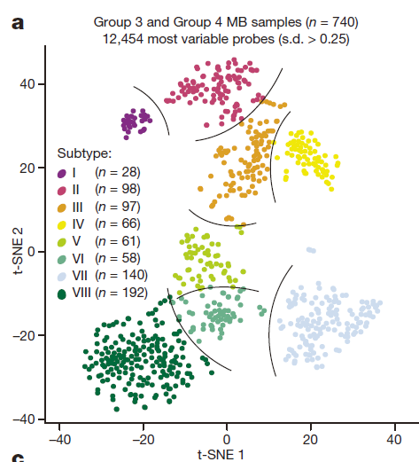

出自https://www.nature.com/articles/nature22973

你可能会卡在两个问题上：R包安装和数据集的预处理。

本代码带你顺利解决这两个问题，画出t-SNE图，把细胞分类和候选marker基因输出到文件。

# 应用场景

场景一：单细胞测序的上百个细胞，识别亚群，找到marker基因；

场景二：上百个肿瘤样本，识别亚型，找到marker基因。像例图那样，用来划分甲基化亚型。

# 环境设置

安装R包`Seurat`。之前的版本对应2.x, 目前版本对应3.x.x.

```r
# loading Seurat
if (! require("Seurat")){
  install.packages('Seurat')
  library(Seurat)
} else{
  library(Seurat)
}
# loading plyr
if (! require(plyr)){
  install.packages("plyr")
  library(plyr)
} else{
  library(plyr)
}

library(ggplot2)
```

**注**: Windows系统用户安装会很顺利。

MacOS/Linux系统用户要有Root权限，或许会因为hdf5r安装失败而无法顺利安装，不要图省事，听报错的话，用`brew install hdf5`。

因为根据hdf5的源代码，它不支持最新的hdf5 1.10.2，最高只支持hdf5 1.10.0，所以请在root权限下根据源码安装。

```bash
wget https://support.hdfgroup.org/ftp/HDF5/releases/hdf5-1.10/hdf5-1.10.0/src/hdf5-1.10.0.tar.gz
tar xf hdf5-1.10.0.tar.gz
cd hdf5-1.10.0
./configure --prefix=/usr/local
make && sudo make install
```

# 数据预处理

请先解压当前目录的下的tung.zip, 里面存放着测试数据集

输入数据是基于UMI的表达矩阵而不是count数据，其中数据集中的行表示基因，列表示细胞。

出自https://www.nature.com/articles/srep39921

## 读取数据

```r
molecules <- read.delim("./tung/molecules.txt",header = TRUE,
           row.names = 1)
dim(molecules)
```

```
## [1] 19027   864
```

```r
#查看前10个基因在前3个细胞中的表达量
molecules[1:10,1:3]
```

```
##                 NA19098.r1.A01 NA19098.r1.A02 NA19098.r1.A03
## ENSG00000237683              0              0              0
## ENSG00000187634              0              0              0
## ENSG00000188976              3              6              1
## ENSG00000187961              0              0              0
## ENSG00000187583              0              0              0
## ENSG00000187642              0              0              0
## ENSG00000188290              0              0              0
## ENSG00000187608              1              7              0
## ENSG00000188157              2              3              2
## ENSG00000237330              0              0              0
```

## 创建Seurat对象

数据初始化，并初步筛选

```r
obj <- CreateSeuratObject(counts = molecules,
                   min.cells = 3, #筛选至少在3个细胞中表达的基因
                   min.features = 200) #筛选至少有200个基因表达的细胞
```

> 2.x版本是min.genes，现在改成了min.features，因为基因也是一种特征， 此外raw.data改成了counts

## 增加Seurat的元信息(metadata)

元信息存放在`obj@meta.data`中，可以是细胞的分组信息，所做处理等，需要自己提供。

此处包含3个人，各96个细胞，各3次重复。

```r
ann <- read.delim("./tung/annotation.txt", header = TRUE)
rownames(ann) <- ann$sample_id
head(ann)
```

```
##                individual replicate well      batch      sample_id
## NA19098.r1.A01    NA19098        r1  A01 NA19098.r1 NA19098.r1.A01
## NA19098.r1.A02    NA19098        r1  A02 NA19098.r1 NA19098.r1.A02
## NA19098.r1.A03    NA19098        r1  A03 NA19098.r1 NA19098.r1.A03
## NA19098.r1.A04    NA19098        r1  A04 NA19098.r1 NA19098.r1.A04
## NA19098.r1.A05    NA19098        r1  A05 NA19098.r1 NA19098.r1.A05
## NA19098.r1.A06    NA19098        r1  A06 NA19098.r1 NA19098.r1.A06
```

```r
summary(ann)
```

```
##    individual  replicate      well            batch              sample_id
##  NA19098:288   r1:288    A01    :  9   NA19098.r1: 96   NA19098.r1.A01:  1
##  NA19101:288   r2:288    A02    :  9   NA19098.r2: 96   NA19098.r1.A02:  1
##  NA19239:288   r3:288    A03    :  9   NA19098.r3: 96   NA19098.r1.A03:  1
##                          A04    :  9   NA19101.r1: 96   NA19098.r1.A04:  1
##                          A05    :  9   NA19101.r2: 96   NA19098.r1.A05:  1
##                          A06    :  9   NA19101.r3: 96   NA19098.r1.A06:  1
##                          (Other):810   (Other)   :288   (Other)       :858
```

检查样品信息跟表达量矩阵的样品是否一致

```r
if (all(rownames(ann) %in% colnames(obj))){
  obj <- AddMetaData(obj, ann)
} else{
  warning("row names should be same to the items in object@cell.names")
}
```

## 过滤掉低质量细胞

根据具体情况来确定标准，进行QC，过滤掉低质量的细胞，此处用`VlnPlot`探索可能的离群值

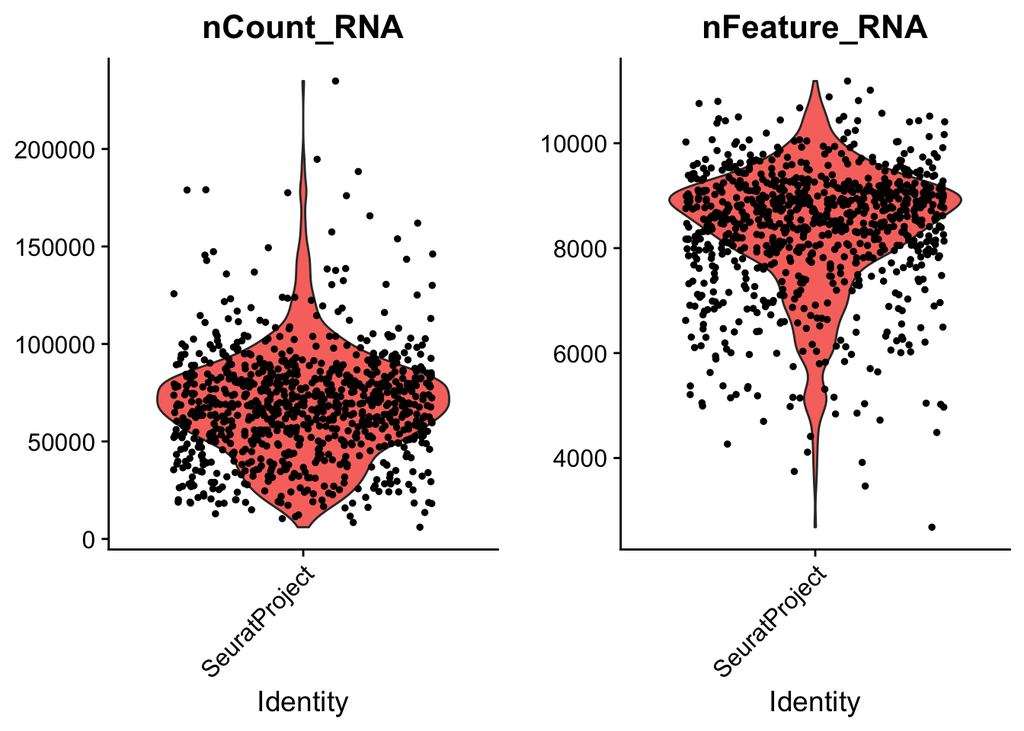

```r
VlnPlot(obj, features = c("nCount_RNA","nFeature_RNA"), group.by = "orig.ident")
```

一般我们会过滤掉过低表达基因的细胞，上图中，你可以认为nCount_RNA低于`25000`、nFeature_RNA低于`6000`的细胞是低质量细胞。把这两个值写到下面过滤细胞的参数中：

```r
obj <- subset(obj, subset = nCount_RNA  > 25000 &
                nFeature_RNA > 6000)
```

此处所用的数据实验深度足够，10X技术单细胞数据标准会不同。

## 标准化

标准化这一步和混池RNA-seq类似，一般不会只使用raw count，而会用log标准化等方式降低其他干扰因素的影响。

```r
obj <- NormalizeData(
    object = obj,
    normalization.method = "LogNormalize",
    scale.factor = 10000
)
```

## 寻找细胞间变化明显的基因

直接使用全部基因进行后续分析对配置要求很高，而是选择那些在细胞中具有明显变化的基因。在降低资源消耗的同时还保证了结果的可靠性。

```r
obj <- FindVariableFeatures(
    object = obj,
    mean.function = ExpMean, #计算x轴的值的方法
    dispersion.function = LogVMR, #计算y轴的值的方法
    do.plot = F,
    x.low.cutoff = 0.0125,
    x.high.cutoff = 3,
    y.cutoff = 0.5
)
```

## 处理混淆因子

所谓的混淆因子(confounder factor) 指的就是目标因素（如实验处理）以外的因素对结果的影响， 比如说批次效应。这些因素掩盖了你真正想研究的目标，所以要尽可能排除。

```r
obj <- ScaleData(
    object = obj,
    vars.to.regress = c("nCount_RNA")
)
```

## 线性降维（PCA）

后续会对细胞进行聚类，直接使用所有特征（即基因）会出现数据挖掘中的“维度爆炸”，即维度越高反而结果越差。因此我们需要用PCA进行线性降维，使用部分主成分代替所有基因进行后续的t-SNE和细胞聚类分析。

根据PCElbowPlot确定主成分个数，曲线变得平缓的横坐标。

这个主成分个数将用在下一部分的`pca_to_use =`参数中

```r
obj <- RunPCA(
    object = obj,
    pc.genes = obj@var.genes,
    do.print = FALSE
)
```

```
## PC_ 1
## Positive:  ENSG00000132507, ENSG00000120437, ENSG00000099817, ENSG00000108953, ENSG00000181061, ENSG00000099901, ENSG00000126457, ENSG00000198830, ENSG00000145425, ENSG00000167996
##     ENSG00000197728, ENSG00000125835, ENSG00000108518, ENSG00000163682, ENSG00000167526, ENSG00000053438, ENSG00000140988, ENSG00000026025, ENSG00000126432, ENSG00000198825
##     ENSG00000240972, ENSG00000160213, ENSG00000105669, ENSG00000164434, ENSG00000110492, ENSG00000185201, ENSG00000184110, ENSG00000115268, ENSG00000162244, ENSG00000198865
## Negative:  ENSG00000106153, ERCC-00002, ERCC-00096, ERCC-00130, ENSG00000088305, ENSG00000147601, ENSG00000241186, ERCC-00004, ERCC-00113, ERCC-00074
##     ENSG00000152061, ERCC-00046, ENSG00000184674, ERCC-00136, ERCC-00003, ERCC-00171, ERCC-00043, ENSG00000066279, ENSG00000143494, ERCC-00145
##     ENSG00000135862, ERCC-00042, ENSG00000154556, ENSG00000139364, ERCC-00108, ENSG00000173726, ENSG00000138035, ENSG00000117724, ERCC-00060, ENSG00000185630
## PC_ 2
## Positive:  ENSG00000170561, ENSG00000128610, ENSG00000182195, ERCC-00009, ENSG00000163191, ENSG00000198825, ERCC-00074, ENSG00000166352, ERCC-00136, ERCC-00108
##     ERCC-00046, ERCC-00171, ERCC-00004, ERCC-00130, ENSG00000154556, ENSG00000164434, ENSG00000165588, ENSG00000105894, ENSG00000203667, ERCC-00002
##     ERCC-00113, ERCC-00096, ERCC-00092, ERCC-00076, ERCC-00043, ERCC-00022, ERCC-00145, ENSG00000179542, ENSG00000148834, ERCC-00042
## Negative:  ENSG00000131969, ENSG00000077458, ENSG00000177954, ENSG00000135549, ENSG00000022556, ENSG00000163106, ENSG00000159228, ENSG00000187193, ENSG00000141543, ENSG00000156508
##     ENSG00000131469, ENSG00000185088, ENSG00000158710, ENSG00000142541, ENSG00000143248, ENSG00000256618, ENSG00000198918, ENSG00000139209, ENSG00000232112, ENSG00000067225
##     ENSG00000124839, ENSG00000137154, ENSG00000180543, ENSG00000129991, ENSG00000165118, ENSG00000102309, ENSG00000065154, ENSG00000137267, ENSG00000179172, ENSG00000166165
## PC_ 3
## Positive:  ENSG00000256618, ENSG00000198865, ENSG00000174721, ENSG00000118523, ENSG00000256045, ENSG00000255823, ENSG00000270672, ENSG00000035403, ENSG00000026025, ENSG00000135549
##     ENSG00000179059, ENSG00000113758, ENSG00000198786, ENSG00000165449, ENSG00000137801, ENSG00000132718, ENSG00000269028, ENSG00000022556, ENSG00000151012, ENSG00000105810
##     ENSG00000255633, ENSG00000197694, ENSG00000198028, ENSG00000162878, ENSG00000072310, ENSG00000142871, ENSG00000147257, ENSG00000271043, ENSG00000158470, ENSG00000198093
## Negative:  ENSG00000163041, ENSG00000185885, ENSG00000116161, ENSG00000163191, ENSG00000134333, ENSG00000164265, ENSG00000240972, ENSG00000166426, ENSG00000143742, ENSG00000163382
##     ENSG00000114023, ENSG00000183648, ENSG00000102144, ENSG00000167863, ENSG00000143771, ENSG00000168275, ENSG00000105379, ENSG00000166347, ENSG00000142534, ENSG00000115268
##     ENSG00000260362, ENSG00000140990, ENSG00000176171, ENSG00000184674, ENSG00000167526, ENSG00000124614, ENSG00000132432, ENSG00000197747, ENSG00000114391, ENSG00000117122
## PC_ 4
## Positive:  ERCC-00003, ERCC-00145, ERCC-00046, ERCC-00171, ERCC-00022, ERCC-00111, ERCC-00009, ERCC-00112, ERCC-00074, ERCC-00042
##     ERCC-00095, ERCC-00004, ERCC-00130, ERCC-00062, ERCC-00096, ERCC-00076, ERCC-00060, ERCC-00043, ERCC-00025, ERCC-00002
##     ERCC-00131, ERCC-00113, ERCC-00108, ERCC-00136, ERCC-00092, ERCC-00071, ERCC-00170, ERCC-00034, ERCC-00035, ERCC-00084
## Negative:  ENSG00000138161, ENSG00000154473, ENSG00000143198, ENSG00000106341, ENSG00000104112, ENSG00000091140, ENSG00000173207, ENSG00000163666, ENSG00000121207, ENSG00000078018
##     ENSG00000105894, ENSG00000138175, ENSG00000170961, ENSG00000123636, ENSG00000164104, ENSG00000174721, ENSG00000139318, ENSG00000180730, ENSG00000112280, ENSG00000142408
##     ENSG00000121769, ENSG00000106211, ENSG00000158164, ENSG00000120885, ENSG00000143353, ENSG00000110172, ENSG00000142669, ENSG00000171617, ENSG00000048540, ENSG00000163041
## PC_ 5
## Positive:  ENSG00000184697, ENSG00000117318, ENSG00000172270, ENSG00000108518, ENSG00000167996, ENSG00000104112, ENSG00000196923, ENSG00000171222, ENSG00000139318, ENSG00000051523
##     ENSG00000175390, ENSG00000113758, ENSG00000077312, ENSG00000116670, ENSG00000143368, ENSG00000105404, ENSG00000181029, ENSG00000074071, ENSG00000103202, ENSG00000167526
##     ENSG00000205581, ENSG00000125835, ENSG00000182154, ENSG00000179271, ENSG00000185883, ENSG00000105701, ENSG00000106211, ENSG00000125534, ENSG00000175550, ENSG00000183828
## Negative:  ENSG00000125148, ENSG00000125144, ENSG00000205358, ENSG00000198417, ENSG00000169715, ENSG00000133316, ENSG00000205364, ENSG00000170312, ENSG00000197747, ENSG00000185885
##     ENSG00000102144, ENSG00000134057, ENSG00000164111, ENSG00000082438, ENSG00000067064, ENSG00000132432, ENSG00000173401, ENSG00000244020, ENSG00000182718, ENSG00000167863
##     ENSG00000087586, ENSG00000180694, ENSG00000067082, ENSG00000171532, ENSG00000187193, ENSG00000114315, ENSG00000128564, ENSG00000182481, ENSG00000143771, ENSG00000173207
```

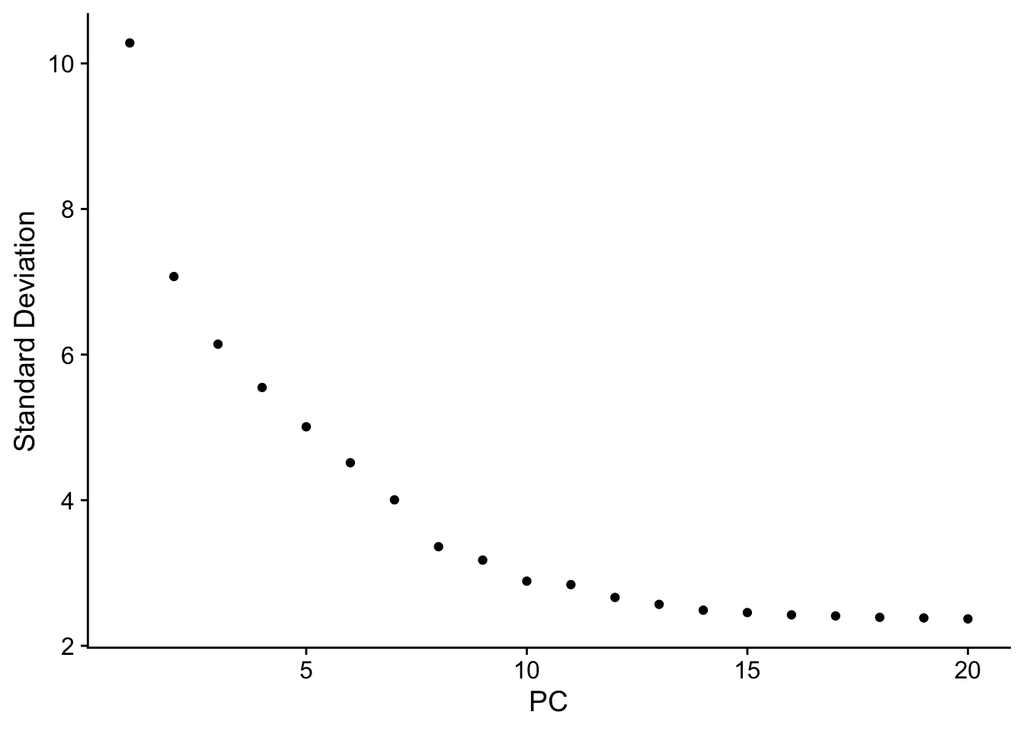

```r
ElbowPlot(object = obj)
```

从图中可以看出：横坐标PC为14时，曲线趋近平缓，因此，此处定为14。

## 细胞聚类

细胞聚类是单细胞分析的关键一步，毕竟大部分研究是想找到新的细胞分群、以前没有发现的细胞类型

```r
pca_to_use <- 14 #上一步主成分的个数
obj <- FindNeighbors(obj, reduction = "pca",
                      dims = 1:pca_to_use)
obj <- FindClusters(object = obj,
                    resolution = 1.0)
```

```
## Modularity Optimizer version 1.3.0 by Ludo Waltman and Nees Jan van Eck
##
## Number of nodes: 815
## Number of edges: 26697
##
## Running Louvain algorithm...
## Maximum modularity in 10 random starts: 0.8812
## Number of communities: 9
## Elapsed time: 0 seconds
```

## t-SNE非线性降维

```r
obj <- RunTSNE(
    object = obj,
    dims = 1:pca_to_use,
    do.fast = TRUE
)
```